Skip to main content

119 **STA 119FS** Statistics as a Way of Thinking

05 / Historic Timeline

# When statistics actually happened.

Introduction Part One · astronomy & geodesy Part Two · the social sciences Part Three · heredity a published work — hover any dot or bar for detail

← Scroll the chart sideways to reach 1950 →

1650

1700

1750

1800

1850

1900

1950

**Britain**London · Woolwich · Oxford · Cambridge · Tunbridge Wells · Greenwich

JG

John Graunt *· London*

**1662** Bills of Mortality

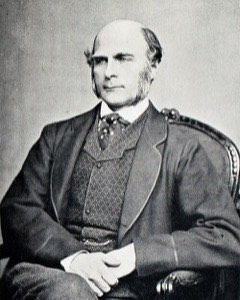

Francis Galton *· London*

**1869**

**1877**

**1888**

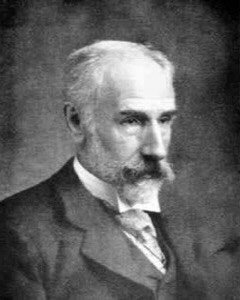

Francis Ysidro Edgeworth *· London · Oxford*

**1885**

**1892**

[figure not shown]

John Arbuthnot *· London*

**1710** Sex ratio at birth

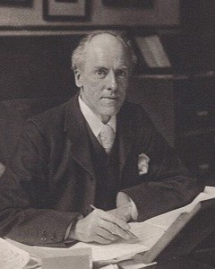

Karl Pearson *· London*

**1895**

**1896**

**1900**

[figure not shown]

Abraham de Moivre *· London*

**1718**

**1733**

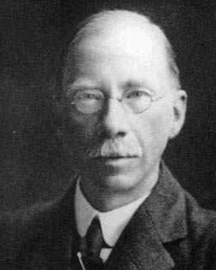

Udny Yule *· London · Cambridge*

**1899** Pauperism

[figure not shown]

Thomas Bayes *· Tunbridge Wells*

**1763** Essay on Chances

[figure not shown]

Thomas Simpson *· Woolwich*

**1755** The mean beats one

**France**Paris · Lyon

[figure not shown]

Pierre-Simon Laplace *· Paris*

**1774** Probability of causes

**1810**

**1812**

[figure not shown]

Adrien-Marie Legendre *· Paris*

**1805** Least squares

[figure not shown]

Siméon Denis Poisson *· Paris*

**1837** Jugements

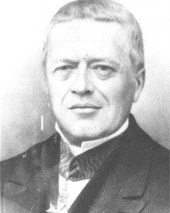

Antoine Augustin Cournot *· Paris · Lyon*

**1843** Exposition

**German lands**Berlin · Nuremberg · Göttingen · Königsberg · Leipzig · Freiburg

[figure not shown]

Leonhard Euler *· Berlin*

**1749** Jupiter & Saturn

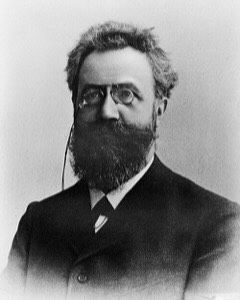

Hermann Ebbinghaus *· Berlin*

**1885** Über das Gedächtnis

[figure not shown]

Tobias Mayer *· Nuremberg · Göttingen*

**1750** Libration of the Moon

[figure not shown]

Carl Friedrich Gauss *· Göttingen*

**1809** Theoria Motus

[figure not shown]

Friedrich Wilhelm Bessel *· Königsberg*

**1823** Personal equation

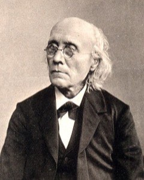

Gustav Fechner *· Leipzig*

**1860** Psychophysik

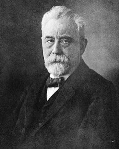

Wilhelm Lexis *· Freiburg · Göttingen*

**1877** Dispersion

**Low Countries**The Hague · Brussels

BK

Baron de Keverberg *· The Hague*

**1827** The de Keverberg dilemma

[figure not shown]

Adolphe Quetelet *· Brussels*

**1835**

**1846**

**Switzerland & Italy**Basel · Rome

[figure not shown]

Jacob Bernoulli *· Basel*

**1713** Ars Conjectandi

[figure not shown]

Roger Joseph Boscovich *· Rome*

**1757** Minimising absolute deviations

**Russia**St Petersburg · Berlin

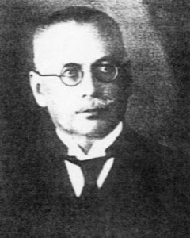

Ladislaus von Bortkiewicz *· St Petersburg · Berlin*

**1898** Law of small numbers

## The ledger

[output not shown]